# **Capstone: Comparative Machine Learning Approaches for Predicting Scale Score Averages**

### **Training ML**

#### **Important: I added comments within the code and/or before/after the code for added explanation.**

```python
# Import packages

import pandas as pd
import numpy as np
import os
import joblib
import seaborn as sns
import matplotlib.pyplot as plt

from sklearn.model_selection import train_test_split, GridSearchCV, cross_val_score, RandomizedSearchCV
from sklearn.linear_model import Ridge
from sklearn.linear_model import Lasso
from sklearn.metrics import r2_score, mean_squared_error, mean_absolute_error
from scipy.stats import pearsonr
from sklearn.tree import DecisionTreeRegressor
from sklearn.preprocessing import StandardScaler
from xgboost import XGBRegressor

# Suppress all warnings
import warnings
warnings.filterwarnings('ignore')

# producing visualizations in notebook
%matplotlib inline

# Ensure all columns are displayed
pd.set_option('display.max_columns', None)  # Show all columns
pd.set_option('display.width', None)       # Adjust display width to avoid wrapping
pd.set_option('display.max_colwidth', None) # Show full content of each column (if needed)

# Function to print bold headers
def print_bold(text):
    print(f"\033[1m{text}\033[0m")
```

## **Data**

The datasets used in this study is taken from Delaware Open Data Council. Two datasets are used in this study, ‘student assessment performance’ dataset and ‘student discipline’ dataset.

> Student Assessment Performance dataset (assessment.csv): https://data.delaware.gov/Education/Student-Assessment-Performance/ms6b-mt82/about_data Student Discipline (discipline.csv): https://data.delaware.gov/Education/Student-Discipline/yr4w-jdi4/about_data

### **Research Question**

**How do traditional regression models compare to tree-based models in predicting school-level Scale Score Averages based on predictive accuracy and model performance metrics?**

## **Hypothesis**

**Null Hypothesis (H₀):** There is no significant difference in predictive accuracy between tree-based models and traditional regression models in predicting school-level Scale Score Averages.

**Alternative Hypothesis (H₁):** Tree-based models demonstrate significantly higher predictive accuracy than traditional regression models in predicting school-level Scale Score Averages.

### **Data storing: All datasets used here are saved in my local data store for a seamless process.**

## Split Data into Training and Testing Sets

```python
def split_data(filepath='4_ready_training.csv', test_size=0.2, random_state=42):
    """
    Load the dataset, convert specific columns to categorical, dynamically select predictor columns,
    and split the data into training and testing sets.

    Parameters:
        filepath (str): Path to the CSV file.
        test_size (float): Proportion of the dataset to include in the test split.
        random_state (int): Random seed for reproducibility.

    Returns:
        X_train (DataFrame): Training predictors.
        X_test (DataFrame): Testing predictors.
        y_train (Series): Training target variable.
        y_test (Series): Testing target variable.
    """
    # Load the dataset
    df = pd.read_csv(filepath)

    # Convert relevant columns to 'category' data type
    df['School Year'] = df['School Year'].astype('category')
    df['Grade_Numeric'] = df['Grade_Numeric'].astype('category')

    # Find relevant columns
    grade_numeric_cols = [col for col in df.columns if col.startswith('Grade_Numeric_')]
    grade_group_cols = [col for col in df.columns if col.startswith('Grade_Group_')]
    category_cols = [col for col in df.columns if col.lower().startswith('category_')]
    content_area_cols = [col for col in df.columns if col.startswith('ContentArea_')]
    special_demo_cols = [col for col in df.columns if col.startswith('SpecialDemo_')]
    district_code_cols = [col for col in df.columns if col.startswith('DistrictCode_')]
    school_year_cols = [col for col in df.columns if col.startswith('SchoolYear_')]
    assessment_name_cols = [col for col in df.columns if col.startswith('AssessmentName_')]

    # Define Dependent and Independent Variables
    y = df['ScaleScoreAvg']

    # Independent Variables (Predictors)
    independent_vars = (
        ['Incidents', 'AvgDuration', 'PctEnrollment'] +
        grade_numeric_cols + grade_group_cols + category_cols +
        content_area_cols + special_demo_cols + district_code_cols +
        school_year_cols + assessment_name_cols
    )

    X = df[independent_vars]

    # Split Data into Training and Testing Sets
    X_train, X_test, y_train, y_test = train_test_split(
        X, y, test_size=test_size, random_state=random_state
    )

    print("\n\nShape of X_train:", X_train.shape)
    print("Shape of X_test:", X_test.shape)
    print("Process successfully!\n")

    return X_train, X_test, y_train, y_test
```

## **Training ML: Traditional Regression Group**

##### Note: Feature Importance is used for all visuals. However, it is specifiec in parenthesis that these are feature coefficients for Lasso and Ridge Regression.

### **Ridge Regression Model**

```python
# Call function: split_data
X_train, X_test, y_train, y_test = split_data()
```

```
Shape of X_train: (519869, 84)
Shape of X_test: (129968, 84)
Process successfully!
```

```
Ridge Regression Analysis Results
R² Score: 0.292510
Mean Squared Error (MSE): 0.279764
Mean Absolute Error (MAE): 0.401849

Pearson Correlation: 0.541, P-value: 0.000

Residual Analysis:
- Mean of residuals: 0.003585
- Standard deviation of residuals: 0.528915
- The mean residual is close to 0, indicating a good fit.

Interpretation: R² Score
- R² reflects the proportion of variance in the target variable explained by the predictors.
  R² Score > 0.7: Strong model.
  0.4 < R² Score ≤ 0.7: Moderate model.
  R² Score ≤ 0.4: Weak model.


Cross-Validation R² Scores: [0.29512694 0.29289429 0.2958661 ]
Mean CV R² Score: 0.29462911180547957
```

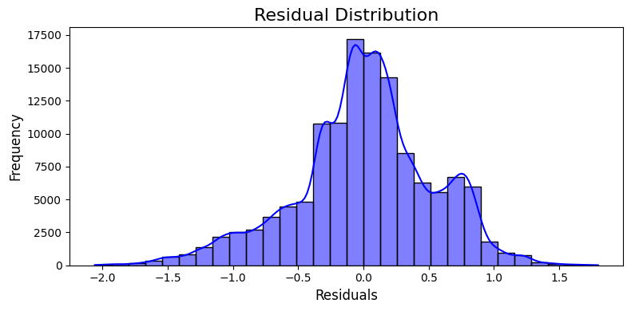

```
Feature Importances (Ridge Regression Coefficients):
PctEnrollment                                           0.283685
AssessmentName_Smarter Balanced Summative Assessment    0.247759
DistrictCode_9606                                       0.132770
DistrictCode_9605                                       0.119697
DistrictCode_88                                         0.087946
DistrictCode_82                                         0.087017
DistrictCode_87                                         0.073664
DistrictCode_9612                                       0.071901
DistrictCode_38                                         0.070775
DistrictCode_85                                         0.064318
dtype: float64
```

[figure not shown]

```
Model saved: saved_models/ridge_reg.joblib
```

```python
# Create a directory for saved models if it doesn't exist
model_dir = "saved_models"
os.makedirs(model_dir, exist_ok=True)

# Fit a Ridge Regression Model
ridge_model = Ridge()
ridge_model.fit(X_train, y_train)

#  Evaluate the Model
y_pred_ridge_nottuned = ridge_model.predict(X_test)
r2 = r2_score(y_test, y_pred_ridge_nottuned)
mse = mean_squared_error(y_test, y_pred_ridge_nottuned)
mae = mean_absolute_error(y_test, y_pred_ridge_nottuned)
correlation, p_value = pearsonr(y_test, y_pred_ridge_nottuned)

print_bold("\n\nRidge Regression Analysis Results")
print(f"R² Score: {r2:.6f}")
print(f"Mean Squared Error (MSE): {mse:.6f}")
print(f"Mean Absolute Error (MAE): {mae:.6f}\n")
print(f"Pearson Correlation: {correlation:.3f}, P-value: {p_value:.3f}")

#  Calculate Residual Metrics
residuals = y_test - y_pred_ridge_nottuned
mean_residual = np.mean(residuals)
std_residual = np.std(residuals)
print("\nResidual Analysis:")
print(f"- Mean of residuals: {mean_residual:.6f}")
print(f"- Standard deviation of residuals: {std_residual:.6f}")
if np.isclose(mean_residual, 0, atol=1e-2):
    print("- The mean residual is close to 0, indicating a good fit.")
else:
    print("- The mean residual is not close to 0, suggesting potential model improvement.")

#  Interpretation
print("\nInterpretation: R² Score")
print("- R² reflects the proportion of variance in the target variable explained by the predictors.")
print("  R² Score > 0.7: Strong model.")
print("  0.4 < R² Score ≤ 0.7: Moderate model.")
print("  R² Score ≤ 0.4: Weak model.\n\n")

#  Cross-Validation Scores
cv_scores = cross_val_score(ridge_model, X_train, y_train, cv=3, scoring='r2')
print("Cross-Validation R² Scores:", cv_scores)
print("Mean CV R² Score:", np.mean(cv_scores))

#  Visualize Residuals
# (Residuals already computed above)
plt.figure(figsize=(8, 4))
sns.histplot(residuals, kde=True, color='blue', bins=30)
plt.title("Residual Distribution", fontsize=16)
plt.xlabel("Residuals", fontsize=12)
plt.ylabel("Frequency", fontsize=12)
plt.tight_layout()
plt.show()

# Feature Importances (Coefficients)
feature_importances = pd.Series(ridge_model.coef_, index=X_train.columns)
feature_importances = feature_importances.sort_values(ascending=False)

print("\nFeature Importances (Ridge Regression Coefficients):")
print(feature_importances.head(10))

# Visualize Feature Importances
plt.figure(figsize=(10, 6))
sns.barplot(x=feature_importances.values, y=feature_importances.index, palette='viridis')
plt.title('Ridge Regression Coefficients', fontsize=16)
plt.xlabel('Coefficient Value', fontsize=12)
plt.ylabel('Feature', fontsize=12)
plt.tight_layout()
plt.show()

# Save model
model_filename = f"{model_dir}/ridge_reg.joblib"
joblib.dump(ridge_model, model_filename)
print(f"Model saved: {model_filename}")
```

```python
# Call function: split_data
X_train, X_test, y_train, y_test = split_data()
```

```
Shape of X_train: (519869, 84)
Shape of X_test: (129968, 84)
Process successfully!
```

```
Fitting 3 folds for each of 6 candidates, totalling 18 fits

=== Best Hyperparameters ===
{'alpha': 1}

=== Ridge Regression Results ===
R² Score: 0.293
MSE: 0.279764
MAE: 0.401849
Pearson Correlation: 0.541, P-value: 0.000

Cross-Validation R² Scores: [0.29512694 0.29289429 0.2958661 ]
Mean CV R² Score: 0.29462911180547957
```

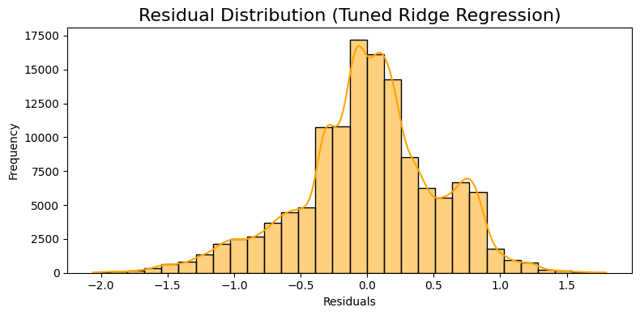

```
Residual Analysis:
- Mean of residuals: 0.003585
- Standard deviation of residuals: 0.528915
- The mean residual is close to 0, indicating a good fit.

Feature Importances (Ridge Regression Coefficients):
PctEnrollment                                           0.283685
AssessmentName_Smarter Balanced Summative Assessment    0.247759
DistrictCode_9606                                       0.132770
DistrictCode_9605                                       0.119697
DistrictCode_88                                         0.087946
DistrictCode_82                                         0.087017
DistrictCode_87                                         0.073664
DistrictCode_9612                                       0.071901
DistrictCode_38                                         0.070775
DistrictCode_85                                         0.064318
dtype: float64
```

[figure not shown]

```
Model saved: saved_models/ridge_model_tuned.joblib
```

```python
# Create a directory for saved models if it doesn't exist
model_dir = "saved_models"
os.makedirs(model_dir, exist_ok=True)

#  Hyperparameter grid for Ridge Regression
param_grid = {
    'alpha': [0.001, 0.01, 0.1, 1, 10, 100],
}

#  GridSearchCV setup
grid_search_ridge = GridSearchCV(
    Ridge(),
    param_grid=param_grid,
    cv=3,
    scoring='r2',
    n_jobs=-1,
    verbose=1
)

# Fit GridSearchCV
grid_search_ridge.fit(X_train, y_train)

#  Predict using best model
best_ridge = grid_search_ridge.best_estimator_
y_pred_ridge = best_ridge.predict(X_test)


#  Evaluation Metrics
r2_ridge = r2_score(y_test, y_pred_ridge)
mse_ridge = mean_squared_error(y_test, y_pred_ridge)
mae_ridge = mean_absolute_error(y_test, y_pred_ridge)
correlation_ridge, p_value_ridge = pearsonr(y_test, y_pred_ridge)

print("\n=== Best Hyperparameters ===")
print(grid_search_ridge.best_params_)

print("\n=== Ridge Regression Results ===")
print(f"R² Score: {r2_ridge:.3f}")
print(f"MSE: {mse_ridge:.6f}")
print(f"MAE: {mae_ridge:.6f}")
print(f"Pearson Correlation: {correlation_ridge:.3f}, P-value: {p_value_ridge:.3f}")

#  Cross-Validation Scores
cv_scores = cross_val_score(best_ridge, X_train, y_train, cv=3, scoring='r2')
print("\nCross-Validation R² Scores:", cv_scores)
print("Mean CV R² Score:", np.mean(cv_scores))

#  Visualize Residuals
residuals_ridge = y_test - y_pred_ridge
plt.figure(figsize=(8, 4))
sns.histplot(residuals_ridge, kde=True, bins=30, color='orange')
plt.title("Residual Distribution (Tuned Ridge Regression)", fontsize=16)
plt.xlabel("Residuals")
plt.ylabel("Frequency")
plt.tight_layout()
plt.show()

#  Calculate Residual Metrics
mean_residual = np.mean(residuals_ridge)
std_residual = np.std(residuals_ridge)
print("\nResidual Analysis:")
print(f"- Mean of residuals: {mean_residual:.6f}")
print(f"- Standard deviation of residuals: {std_residual:.6f}")
if np.isclose(mean_residual, 0, atol=1e-2):
    print("- The mean residual is close to 0, indicating a good fit.")
else:
    print("- The mean residual is not close to 0, suggesting potential model improvement.")

# Feature Importances (Coefficients)
feature_importances = pd.Series(best_ridge.coef_, index=X_train.columns)
feature_importances = feature_importances.sort_values(ascending=False)

print("\nFeature Importances (Ridge Regression Coefficients):")
print(feature_importances.head(10))

# Visualize Feature Importances
plt.figure(figsize=(10, 6))
sns.barplot(x=feature_importances.values, y=feature_importances.index, palette='viridis')
plt.title('Ridge Regression Coefficients', fontsize=16)
plt.xlabel('Coefficient Value', fontsize=12)
plt.ylabel('Feature', fontsize=12)
plt.tight_layout()
plt.show()

#  Save Model
model_filename = f"{model_dir}/ridge_model_tuned.joblib"
joblib.dump(best_ridge, model_filename)
print(f"Model saved: {model_filename}")
```

## **Lasso Regression Model**

```python
# Call function: split_data
X_train, X_test, y_train, y_test = split_data()
```

```
Shape of X_train: (519869, 84)
Shape of X_test: (129968, 84)
Process successfully!
```

```
=== Lasso Regression Results ===
R² Score: -0.000032
Mean Squared Error (MSE): 0.395445
Mean Absolute Error (MAE): 0.506775
Pearson Correlation: nan, P-value: nan

Cross-Validation R² Scores: [-2.23037546e-06 -7.59538655e-07 -3.89627643e-07]
Mean CV R² Score: -1.1265139201466212e-06
```

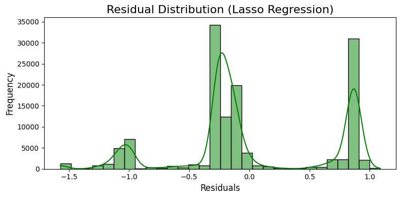

```
Residual Analysis:
- Mean of residuals: 0.003556
- Standard deviation of residuals: 0.628834
- The mean residual is close to 0, indicating a good fit.

Feature Importances (Lasso Regression Coefficients):
Incidents         -0.0
DistrictCode_72   -0.0
DistrictCode_87   -0.0
DistrictCode_86   -0.0
DistrictCode_85   -0.0
DistrictCode_82   -0.0
DistrictCode_80   -0.0
DistrictCode_77   -0.0
DistrictCode_76   -0.0
DistrictCode_74   -0.0
dtype: float64
```

[figure not shown]

```
Model saved: saved_models/lasso_regression_model.joblib
```

```python
# Create a directory for saved models if it doesn't exist
model_dir = "saved_models"
os.makedirs(model_dir, exist_ok=True)

# Initialize and fit the Lasso Regression model
lasso_model = Lasso(alpha=1.0, random_state=42)
lasso_model.fit(X_train, y_train)

# Predict using Lasso Regression
y_pred_lasso = lasso_model.predict(X_test)

# Evaluate Lasso Model
r2_lasso = r2_score(y_test, y_pred_lasso)
mse_lasso = mean_squared_error(y_test, y_pred_lasso)
mae_lasso = mean_absolute_error(y_test, y_pred_lasso)
correlation_lasso, p_value_lasso = pearsonr(y_test, y_pred_lasso)

print("\n\n=== Lasso Regression Results ===")
print(f"R² Score: {r2_lasso:.6f}")
print(f"Mean Squared Error (MSE): {mse_lasso:.6f}")
print(f"Mean Absolute Error (MAE): {mae_lasso:.6f}")
print(f"Pearson Correlation: {correlation_lasso:.3f}, P-value: {p_value_lasso:.3f}")

#  Cross-Validation Scores
cv_scores = cross_val_score(lasso_model, X_train, y_train, cv=3, scoring='r2')
print("\nCross-Validation R² Scores:", cv_scores)
print("Mean CV R² Score:", np.mean(cv_scores))

#  Residual Analysis for Lasso Regression
residuals_lasso = y_test - y_pred_lasso

plt.figure(figsize=(8, 4))
sns.histplot(residuals_lasso, kde=True, color='green', bins=30)
plt.title("Residual Distribution (Lasso Regression)", fontsize=16)
plt.xlabel("Residuals", fontsize=12)
plt.ylabel("Frequency", fontsize=12)
plt.tight_layout()
plt.show()

#  Calculate Residual Metrics
mean_residual = np.mean(residuals_lasso)
std_residual = np.std(residuals_lasso)
print("\nResidual Analysis:")
print(f"- Mean of residuals: {mean_residual:.6f}")
print(f"- Standard deviation of residuals: {std_residual:.6f}")
if np.isclose(mean_residual, 0, atol=1e-2):
    print("- The mean residual is close to 0, indicating a good fit.")
else:
    print("- The mean residual is not close to 0, suggesting potential model improvement.")

#  Feature Importance from Lasso Regression
# For Lasso, the model coefficients represent feature importance.
coefficients = pd.Series(lasso_model.coef_, index=X_train.columns)
# Sort features by the absolute value of coefficients in descending order
coefficients = coefficients.loc[coefficients.abs().sort_values(ascending=False).index]

print("\nFeature Importances (Lasso Regression Coefficients):")
print(coefficients.head(10))

plt.figure(figsize=(10, 6))
coefficients.head(10).plot(kind='bar', color='skyblue')
plt.title('Top 10 Feature Importances (Lasso Regression)', fontsize=16)
plt.xlabel('Features', fontsize=12)
plt.ylabel('Coefficient Value', fontsize=12)
plt.xticks(rotation=45)
plt.tight_layout()
plt.show()

#  Save the Lasso Regression Model
model_filename = f"{model_dir}/lasso_regression_model.joblib"
joblib.dump(lasso_model, model_filename)
print(f"\nModel saved: {model_filename}")
```

```python
# Call function: split_data
X_train, X_test, y_train, y_test = split_data()
```

```
Shape of X_train: (519869, 84)
Shape of X_test: (129968, 84)
Process successfully!
```

```
Hyperparameter Tuning with RandomizedSearchCV (Lasso Regression)


Lasso Regression Results After Hyperparameter Tuning
R² Score: 0.289
Mean Squared Error (MSE): 0.281102
Mean Absolute Error (MAE): 0.403611
Pearson Correlation: 0.538, P-value: 0.000

Cross-Validation R² Scores: [0.2915587  0.28941561 0.29208666]
Mean CV R² Score: 0.29102032480315687

Best Hyperparameters found by RandomizedSearchCV:
{'max_iter': 1000, 'alpha': 0.001}
```

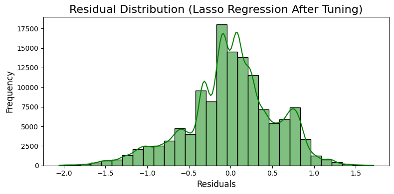

```
Residual Analysis:
- Mean of residuals: 0.003544
- Standard deviation of residuals: 0.530179
- The mean residual is close to 0, indicating a good fit.

Feature Importances (Lasso Regression Coefficients):
Incidents                                                      -1.511145
PctEnrollment                                                   0.281220
AssessmentName_Smarter Balanced Summative Assessment            0.236320
AssessmentName_SAT School-Day (Spring)                         -0.163387
AssessmentName_Delaware System of Student Assessment (DeSSA)   -0.123425
ContentArea_Essay                                              -0.076836
ContentArea_Social Studies                                     -0.047034
SchoolYear_2019                                                 0.036298
category_Expulsion (Permanent Removal from School)              0.035242
SchoolYear_2022                                                -0.027942
dtype: float64
```

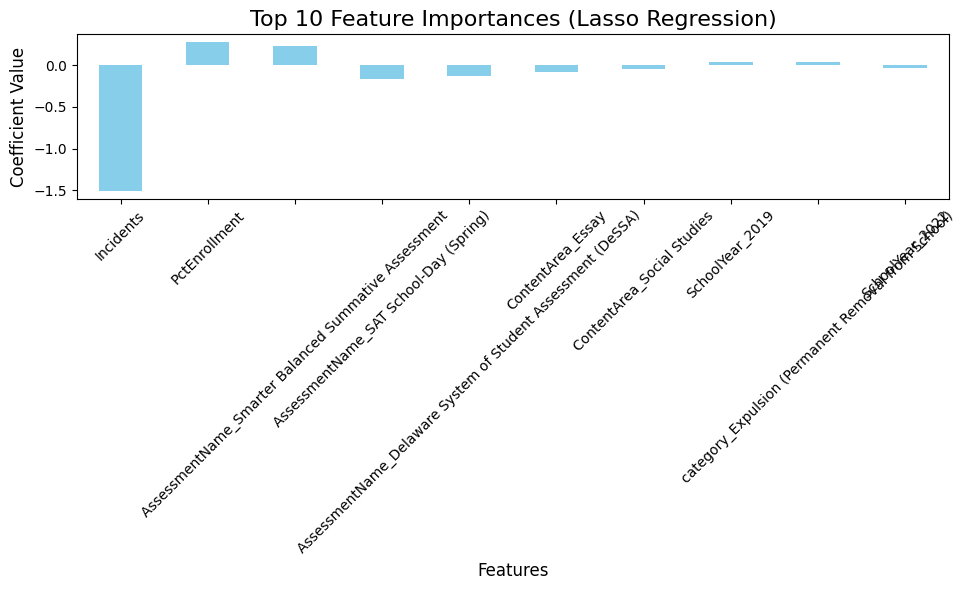

```
Best model saved: saved_models/lasso_regression_model_tuned.joblib
```

```python
# Create a directory for saved models if it doesn't exist
model_dir = "saved_models"
os.makedirs(model_dir, exist_ok=True)

#  Hyperparameter Tuning with RandomizedSearchCV
print_bold("\nHyperparameter Tuning with RandomizedSearchCV (Lasso Regression)")

# Define the parameter grid for Lasso Regression
param_dist = {
    'alpha': [0.001, 0.01, 0.1, 1.0, 10.0],
    'max_iter': [1000, 5000, 10000]
}

# Initialize the Lasso Regression model
lasso_model = Lasso(random_state=42)

# Initialize RandomizedSearchCV
random_search = RandomizedSearchCV(
    estimator=lasso_model,
    param_distributions=param_dist,
    n_iter=10,
    scoring='r2',
    cv=3,
    random_state=42,
    n_jobs=-1
)

# Fit the random search model
random_search.fit(X_train, y_train)

# Get the best Lasso model from the random search
best_lasso_model = random_search.best_estimator_

# Predict using the best model
y_pred_lasso_tuned = best_lasso_model.predict(X_test)


# Evaluate the best model
r2_lasso = r2_score(y_test, y_pred_lasso_tuned)
mse_lasso = mean_squared_error(y_test, y_pred_lasso_tuned)
mae_lasso = mean_absolute_error(y_test, y_pred_lasso_tuned)
correlation_lasso, p_value_lasso = pearsonr(y_test, y_pred_lasso_tuned)

print_bold("\n\nLasso Regression Results After Hyperparameter Tuning")
print(f"R² Score: {r2_lasso:.3f}")
print(f"Mean Squared Error (MSE): {mse_lasso:.6f}")
print(f"Mean Absolute Error (MAE): {mae_lasso:.6f}")
print(f"Pearson Correlation: {correlation_lasso:.3f}, P-value: {p_value_lasso:.3f}")

#  Cross-Validation Scores
cv_scores = cross_val_score(best_lasso_model, X_train, y_train, cv=3, scoring='r2')
print("\nCross-Validation R² Scores:", cv_scores)
print("Mean CV R² Score:", np.mean(cv_scores))

# Display the best hyperparameters found by RandomizedSearchCV
print("\nBest Hyperparameters found by RandomizedSearchCV:")
print(random_search.best_params_)

#  Feature Importance from the Best Lasso Model
# For Lasso, the model coefficients serve as feature importances.
coefficients = pd.Series(best_lasso_model.coef_, index=X_train.columns)
# Sort by the absolute value of the coefficients in descending order
coefficients = coefficients.loc[coefficients.abs().sort_values(ascending=False).index]

# Residual Analysis for Lasso Regression
residuals_lasso_tuned = y_test - y_pred_lasso_tuned

plt.figure(figsize=(8, 4))
sns.histplot(residuals_lasso_tuned, kde=True, color='green', bins=30)
plt.title("Residual Distribution (Lasso Regression After Tuning)", fontsize=16)
plt.xlabel("Residuals", fontsize=12)
plt.ylabel("Frequency", fontsize=12)
plt.tight_layout()
plt.show()

# Calculate Residual Metrics
mean_residual = np.mean(residuals_lasso_tuned)
std_residual = np.std(residuals_lasso_tuned)
print("\nResidual Analysis:")
print(f"- Mean of residuals: {mean_residual:.6f}")
print(f"- Standard deviation of residuals: {std_residual:.6f}")
if np.isclose(mean_residual, 0, atol=1e-2):
    print("- The mean residual is close to 0, indicating a good fit.")
else:
    print("- The mean residual is not close to 0, suggesting potential model improvement.")

print("\nFeature Importances (Lasso Regression Coefficients):")
print(coefficients.head(10))

plt.figure(figsize=(10, 6))
coefficients.head(10).plot(kind='bar', color='skyblue')
plt.title('Top 10 Feature Importances (Lasso Regression)', fontsize=16)
plt.xlabel('Features', fontsize=12)
plt.ylabel('Coefficient Value', fontsize=12)
plt.xticks(rotation=45)
plt.tight_layout()
plt.show()

# Save the Best Lasso Regression Model
model_filename = f"{model_dir}/lasso_regression_model_tuned.joblib"
joblib.dump(best_lasso_model, model_filename)
print(f"\nBest model saved: {model_filename}")
```

### **Decision Tree Regressor**

```python
# Call function: split_data
X_train, X_test, y_train, y_test = split_data()
```

```
Shape of X_train: (519869, 84)
Shape of X_test: (129968, 84)
Process successfully!
```

```
=== Decision Tree Regression Results ===
R² Score: 0.741542
Mean Squared Error (MSE): 0.102202
Mean Absolute Error (MAE): 0.177782
Pearson Correlation: 0.861, P-value: 0.000

Cross-Validation R² Scores: [0.73905386 0.72939229 0.73929941]
Mean CV R² Score: 0.7359151879355927
```

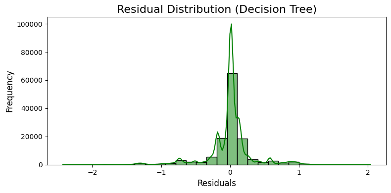

```
Residual Analysis:
- Mean of residuals: 0.000940
- Standard deviation of residuals: 0.319690
- The mean residual is close to 0, indicating a good fit.

Feature Importances (Decision Tree):
Incidents                                               0.394420
AvgDuration                                             0.309712
PctEnrollment                                           0.264387
AssessmentName_Smarter Balanced Summative Assessment    0.030266
category_Suspended                                      0.001051
ContentArea_Computer Science                            0.000164
Grade_Group_Elementary                                  0.000000
DistrictCode_76                                         0.000000
DistrictCode_88                                         0.000000
DistrictCode_87                                         0.000000
dtype: float64
```

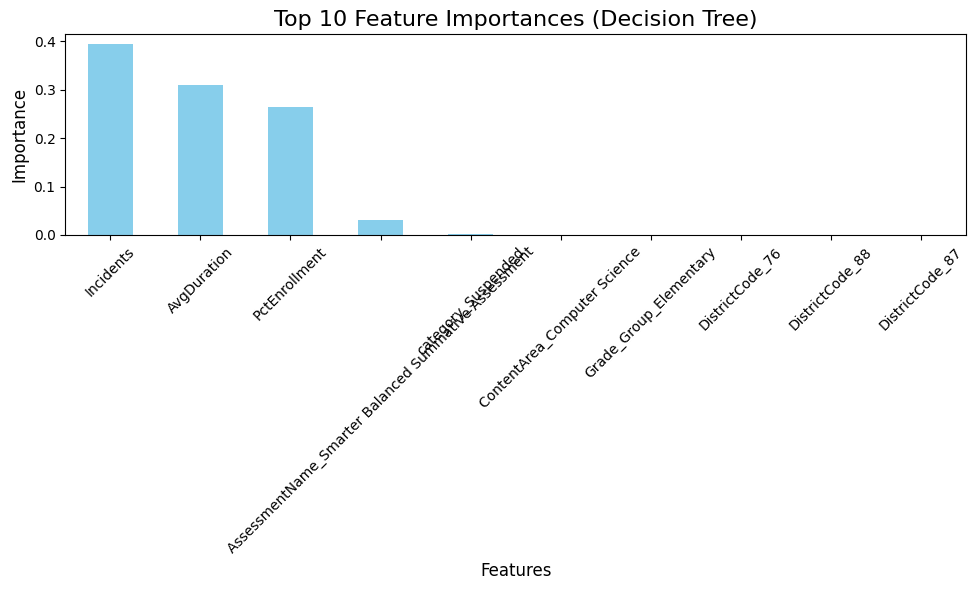

```
Model saved: saved_models/decision_tree_model.joblib
```

```python
# Create a directory for saved models if it doesn't exist
model_dir = "saved_models"
os.makedirs(model_dir, exist_ok=True)

# Initialize and fit the Decision Tree Regressor
dt_model = DecisionTreeRegressor(max_depth=5, random_state=42)
dt_model.fit(X_train, y_train)

# Predict using Decision Tree Regressor
y_pred_dt = dt_model.predict(X_test)

# Evaluate Decision Tree Model
r2_dt = r2_score(y_test, y_pred_dt)
mse_dt = mean_squared_error(y_test, y_pred_dt)
mae_dt = mean_absolute_error(y_test, y_pred_dt)
correlation_dt, p_value_dt = pearsonr(y_test, y_pred_dt)

print("\n\n=== Decision Tree Regression Results ===")
print(f"R² Score: {r2_dt:.6f}")
print(f"Mean Squared Error (MSE): {mse_dt:.6f}")
print(f"Mean Absolute Error (MAE): {mae_dt:.6f}")
print(f"Pearson Correlation: {correlation_dt:.3f}, P-value: {p_value_dt:.3f}")

#  Cross-Validation Scores
cv_scores = cross_val_score(dt_model, X_train, y_train, cv=3, scoring='r2')
print("\nCross-Validation R² Scores:", cv_scores)
print("Mean CV R² Score:", np.mean(cv_scores))

#  Residual Analysis for Decision Tree
residuals_dt = y_test - y_pred_dt

plt.figure(figsize=(8, 4))
sns.histplot(residuals_dt, kde=True, color='green', bins=30)
plt.title("Residual Distribution (Decision Tree)", fontsize=16)
plt.xlabel("Residuals", fontsize=12)
plt.ylabel("Frequency", fontsize=12)
plt.tight_layout()
plt.show()

#  Calculate Residual Metrics
mean_residual = np.mean(residuals_dt)
std_residual = np.std(residuals_dt)
print("\nResidual Analysis:")
print(f"- Mean of residuals: {mean_residual:.6f}")
print(f"- Standard deviation of residuals: {std_residual:.6f}")
if np.isclose(mean_residual, 0, atol=1e-2):
    print("- The mean residual is close to 0, indicating a good fit.")
else:
    print("- The mean residual is not close to 0, suggesting potential model improvement.")

#  Feature Importance from Decision Tree
feature_importances = pd.Series(dt_model.feature_importances_, index=X_train.columns)
feature_importances = feature_importances.sort_values(ascending=False)

print("\nFeature Importances (Decision Tree):")
print(feature_importances.head(10))

plt.figure(figsize=(10, 6))
feature_importances.head(10).plot(kind='bar', color='skyblue')
plt.title('Top 10 Feature Importances (Decision Tree)', fontsize=16)
plt.xlabel('Features', fontsize=12)
plt.ylabel('Importance', fontsize=12)
plt.xticks(rotation=45)
plt.tight_layout()
plt.show()

#  Save the Decision Tree Model
model_filename = f"{model_dir}/decision_tree_model.joblib"
joblib.dump(dt_model, model_filename)
print(f"\nModel saved: {model_filename}")
```

### **Decision Tree Regressor: Hyperparameter Tuning with RandomizedSearchCV**

```python
# Call function: split_data
X_train, X_test, y_train, y_test = split_data()
```

```
Shape of X_train: (519869, 84)
Shape of X_test: (129968, 84)
Process successfully!
```

```
Hyperparameter Tuning with RandomizedSearchCV (Decision Tree Regression)


Decision Tree Regression Results After Hyperparameter Tuning
R² Score: 0.852
Mean Squared Error (MSE): 0.058364
Mean Absolute Error (MAE): 0.117435
Pearson Correlation: 0.923, P-value: 0.000

Cross-Validation R² Scores: [0.8477795  0.84962428 0.84856838]
Mean CV R² Score: 0.8486573891425078

Best Hyperparameters found by RandomizedSearchCV:
{'min_samples_split': 5, 'min_samples_leaf': 1, 'max_features': None, 'max_depth': 10}
```

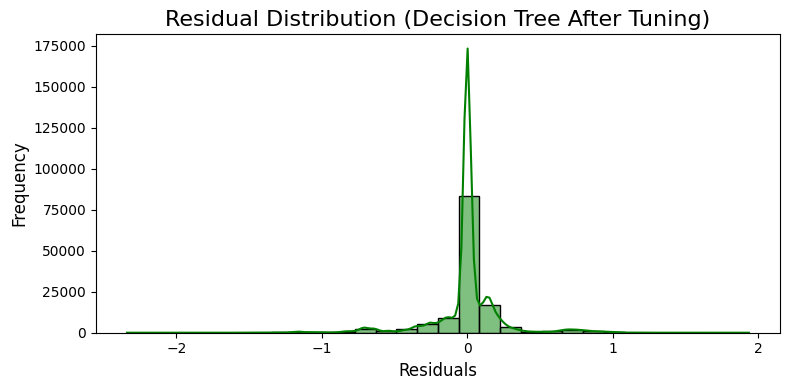

```
Residual Analysis:
- Mean of residuals: -0.000297
- Standard deviation of residuals: 0.241586
- The mean residual is close to 0, indicating a good fit.

Feature Importances (Best Decision Tree Model):
Incidents                                                       0.385484
AvgDuration                                                     0.312013
PctEnrollment                                                   0.254819
AssessmentName_Smarter Balanced Summative Assessment            0.032142
ContentArea_Essay                                               0.003676
SchoolYear_2022                                                 0.001944
category_Out-of-School Suspension_Merged                        0.001755
AssessmentName_Delaware System of Student Assessment (DeSSA)    0.001464
AssessmentName_SAT School-Day (Spring)                          0.001355
category_Suspended                                              0.000910
dtype: float64
```

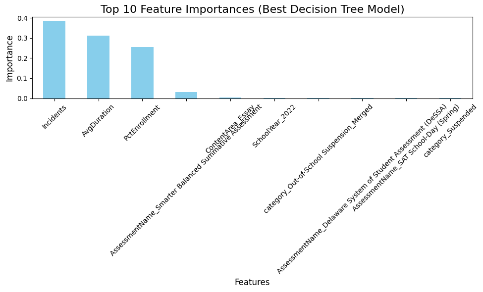

```
Best model saved: saved_models/decision_tree_model_tuned.joblib
```

```python
# Create a directory for saved models if it doesn't exist
model_dir = "saved_models"
os.makedirs(model_dir, exist_ok=True)

# Hyperparameter Tuning with RandomizedSearchCV
print_bold("\nHyperparameter Tuning with RandomizedSearchCV (Decision Tree Regression)")

# Define the parameter grid
param_dist = {
    'max_depth': [None, 3, 5, 7, 10],
    'min_samples_split': [2, 5, 10],
    'min_samples_leaf': [1, 2, 4],
    'max_features': [None, 'auto', 'sqrt', 'log2']
}

# Initialize the Decision Tree Regressor
dt_model = DecisionTreeRegressor(random_state=42)

# Initialize RandomizedSearchCV
random_search = RandomizedSearchCV(
    estimator=dt_model,
    param_distributions=param_dist,
    n_iter=10,
    scoring='r2',
    cv=3,
    random_state=42,
    n_jobs=-1
)

# Fit the random search model
random_search.fit(X_train, y_train)

# Get the best Decision Tree model from the random search
best_dt_model = random_search.best_estimator_

# Predict using the best model
y_pred_dt_tuned = best_dt_model.predict(X_test)

# Evaluate the best model
r2_dt = r2_score(y_test, y_pred_dt_tuned)
mse_dt = mean_squared_error(y_test, y_pred_dt_tuned)
mae_dt = mean_absolute_error(y_test, y_pred_dt_tuned)
correlation_dt, p_value_dt = pearsonr(y_test, y_pred_dt_tuned)

print_bold("\n\nDecision Tree Regression Results After Hyperparameter Tuning")
print(f"R² Score: {r2_dt:.3f}")
print(f"Mean Squared Error (MSE): {mse_dt:.6f}")
print(f"Mean Absolute Error (MAE): {mae_dt:.6f}")
print(f"Pearson Correlation: {correlation_dt:.3f}, P-value: {p_value_dt:.3f}")

#  Cross-Validation Scores
cv_scores = cross_val_score(best_dt_model, X_train, y_train, cv=3, scoring='r2')
print("\nCross-Validation R² Scores:", cv_scores)
print("Mean CV R² Score:", np.mean(cv_scores))

# Display the best hyperparameters found by RandomizedSearchCV
print("\nBest Hyperparameters found by RandomizedSearchCV:")
print(random_search.best_params_)

#  Feature Importance from the Best Decision Tree Model
feature_importances = pd.Series(best_dt_model.feature_importances_, index=X_train.columns)
feature_importances = feature_importances.sort_values(ascending=False)

#  Residual Analysis for Decision Tree Regression
residuals_dt_tuned = y_test - y_pred_dt_tuned

plt.figure(figsize=(8, 4))
sns.histplot(residuals_dt_tuned, kde=True, color='green', bins=30)
plt.title("Residual Distribution (Decision Tree After Tuning)", fontsize=16)
plt.xlabel("Residuals", fontsize=12)
plt.ylabel("Frequency", fontsize=12)
plt.tight_layout()
plt.show()

#  Calculate Residual Metrics
mean_residual = np.mean(residuals_dt_tuned)
std_residual = np.std(residuals_dt_tuned)
print("\nResidual Analysis:")
print(f"- Mean of residuals: {mean_residual:.6f}")
print(f"- Standard deviation of residuals: {std_residual:.6f}")
if np.isclose(mean_residual, 0, atol=1e-2):
    print("- The mean residual is close to 0, indicating a good fit.")
else:
    print("- The mean residual is not close to 0, suggesting potential model improvement.")

print("\nFeature Importances (Best Decision Tree Model):")
print(feature_importances.head(10))

plt.figure(figsize=(10, 6))
feature_importances.head(10).plot(kind='bar', color='skyblue')
plt.title('Top 10 Feature Importances (Best Decision Tree Model)', fontsize=16)
plt.xlabel('Features', fontsize=12)
plt.ylabel('Importance', fontsize=12)
plt.xticks(rotation=45)
plt.tight_layout()
plt.show()

#  Save the Best Decision Tree Model
model_filename = f"{model_dir}/decision_tree_model_tuned.joblib"
joblib.dump(best_dt_model, model_filename)
print(f"\nBest model saved: {model_filename}")
```

### **XGBoost Regressor**

```python
# Call function: split_data
X_train, X_test, y_train, y_test = split_data()
```

```
Shape of X_train: (519869, 84)
Shape of X_test: (129968, 84)
Process successfully!
```

```
=== XGBoost Regression Results ===
R² Score: 0.842192
Mean Squared Error (MSE): 0.062402
Mean Absolute Error (MAE): 0.135715
Pearson Correlation: 0.918, P-value: 0.000

Cross-Validation R² Scores: [0.83951415 0.83915408 0.8385428 ]
Mean CV R² Score: 0.8390703440787001
```

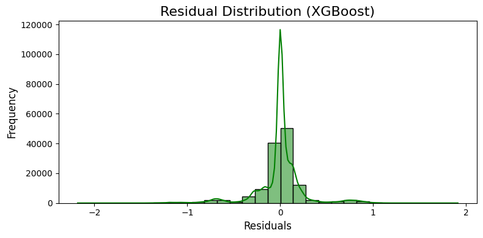

```
Residual Analysis:
- Mean of residuals: 0.000586
- Standard deviation of residuals: 0.249804
- The mean residual is close to 0, indicating a good fit.

Feature Importances (XGBoost):
PctEnrollment                                                   0.212727
Incidents                                                       0.184378
AvgDuration                                                     0.164079
AssessmentName_Smarter Balanced Summative Assessment            0.152896
category_Suspended                                              0.043352
ContentArea_Essay                                               0.030131
AssessmentName_Delaware System of Student Assessment (DeSSA)    0.029917
AssessmentName_SAT School-Day (Spring)                          0.027834
AssessmentName_DeSSA Alternate Assessment                       0.022732
SchoolYear_2022                                                 0.014596
dtype: float32
```

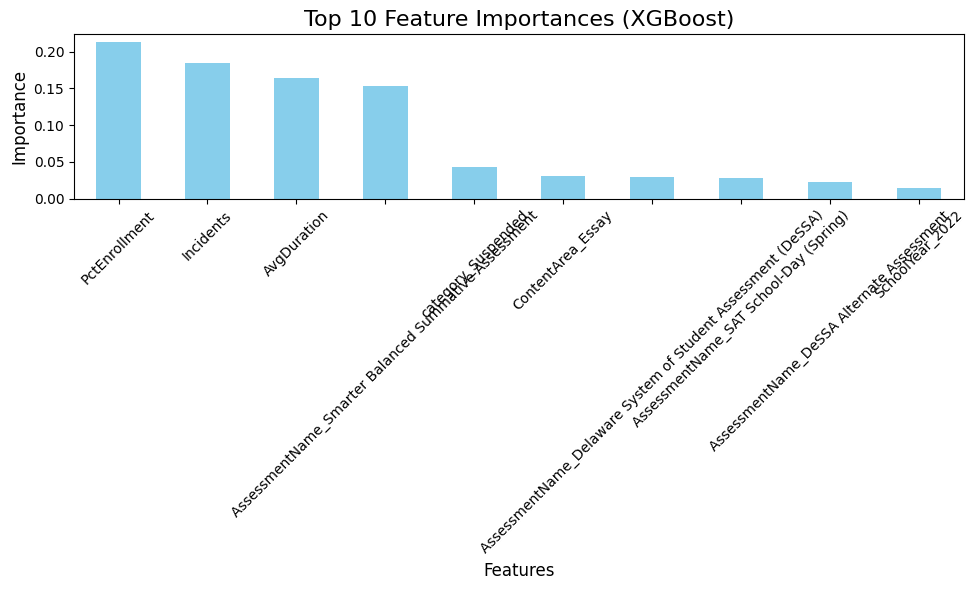

```
Model saved: saved_models/XGBoost_Regressor.joblib
```

```python
# Create a directory for saved models if it doesn't exist
model_dir = "saved_models"
os.makedirs(model_dir, exist_ok=True)

# Initialize and fit the XGBoost model
xgb_model = XGBRegressor(n_estimators=100, learning_rate=0.1, max_depth=5, random_state=42)
xgb_model.fit(X_train, y_train)

# Predict using XGBoost
y_pred_xgb = xgb_model.predict(X_test)

# Evaluate XGBoost Model
r2_xgb = r2_score(y_test, y_pred_xgb)
mse_xgb = mean_squared_error(y_test, y_pred_xgb)
mae_xgb = mean_absolute_error(y_test, y_pred_xgb)
correlation_dt, p_value_dt = pearsonr(y_test, y_pred_xgb)


print("\n\n=== XGBoost Regression Results ===")
print(f"R² Score: {r2_xgb:.6f}")
print(f"Mean Squared Error (MSE): {mse_xgb:.6f}")
print(f"Mean Absolute Error (MAE): {mae_xgb:.6f}")
print(f"Pearson Correlation: {correlation_dt:.3f}, P-value: {p_value_dt:.3f}")

#  Cross-Validation Scores
cv_scores = cross_val_score(xgb_model, X_train, y_train, cv=3, scoring='r2')
print("\nCross-Validation R² Scores:", cv_scores)
print("Mean CV R² Score:", np.mean(cv_scores))

#  Residual Analysis for XGBoost
residuals_xgb = y_test - y_pred_xgb

plt.figure(figsize=(8, 4))
sns.histplot(residuals_xgb, kde=True, color='green', bins=30)
plt.title("Residual Distribution (XGBoost)", fontsize=16)
plt.xlabel("Residuals", fontsize=12)
plt.ylabel("Frequency", fontsize=12)
plt.tight_layout()
plt.show()

# Calculate Residual Metrics
mean_residual = np.mean(residuals_xgb)
std_residual = np.std(residuals_xgb)
print("\nResidual Analysis:")
print(f"- Mean of residuals: {mean_residual:.6f}")
print(f"- Standard deviation of residuals: {std_residual:.6f}")
if np.isclose(mean_residual, 0, atol=1e-2):
    print("- The mean residual is close to 0, indicating a good fit.")
else:
    print("- The mean residual is not close to 0, suggesting potential model improvement.")

#  Feature Importance from XGBoost
feature_importances = pd.Series(xgb_model.feature_importances_, index=X_train.columns)
feature_importances = feature_importances.sort_values(ascending=False)

print("\nFeature Importances (XGBoost):")
print(feature_importances.head(10))

plt.figure(figsize=(10, 6))
feature_importances.head(10).plot(kind='bar', color='skyblue')
plt.title('Top 10 Feature Importances (XGBoost)', fontsize=16)
plt.xlabel('Features', fontsize=12)
plt.ylabel('Importance', fontsize=12)
plt.xticks(rotation=45)
plt.tight_layout()
plt.show()

#  Save the XGBoost Model
model_filename = f"{model_dir}/XGBoost_Regressor.joblib"
joblib.dump(xgb_model, model_filename)
print(f"\nModel saved: {model_filename}")
```

### **XGBoost Regressor: Hyperparameter Tuning with RandomizedSearchCV**

```python
# Call function: split_data
X_train, X_test, y_train, y_test = split_data()
```

```
Shape of X_train: (519869, 84)
Shape of X_test: (129968, 84)
Process successfully!
```

```
Hyperparameter Tuning with RandomizedSearchCV (XGBoost)


XGBoost Regression Results After Hyperparameter Tuning
R² Score: 0.865
Mean Squared Error (MSE): 0.053433
Mean Absolute Error (MAE): 0.118371
Pearson Correlation: 0.930, P-value: 0.000

Cross-Validation R² Scores: [0.86180015 0.86157849 0.86200565]
Mean CV R² Score: 0.8617947644426805

Best Hyperparameters found by RandomizedSearchCV:
{'subsample': 0.8, 'n_estimators': 200, 'min_child_weight': 1, 'max_depth': 7, 'learning_rate': 0.2, 'gamma': 0.1, 'colsample_bytree': 0.6}
```

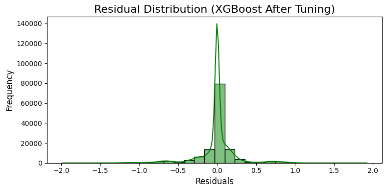

```
Residual Analysis:
- Mean of residuals: 0.000088
- Standard deviation of residuals: 0.231156
- The mean residual is close to 0, indicating a good fit.

Feature Importances (Best XGBoost Model):
AvgDuration                                                     0.243002
Incidents                                                       0.191493
AssessmentName_Smarter Balanced Summative Assessment            0.107642
PctEnrollment                                                   0.042667
AssessmentName_Delaware System of Student Assessment (DeSSA)    0.039766
AssessmentName_SAT School-Day (Spring)                          0.033250
ContentArea_Mathematics                                         0.031046
category_Suspended                                              0.021201
AssessmentName_DeSSA Alternate Assessment                       0.018355
ContentArea_English Language Arts                               0.017583
dtype: float32
```

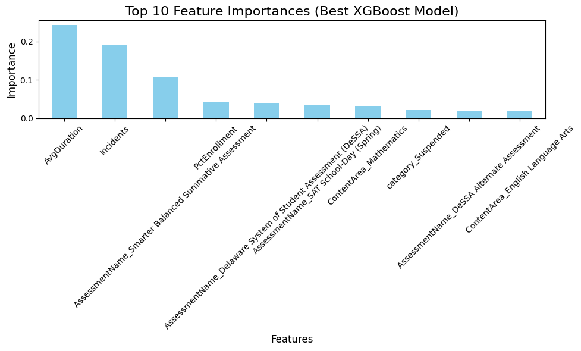

```
Best model saved: saved_models/XGBoost_Regressor_Tuned.joblib
```

```python
# Create a directory for saved models if it doesn't exist
model_dir = "saved_models"
os.makedirs(model_dir, exist_ok=True)

#  Hyperparameter Tuning with RandomizedSearchCV
print_bold("\nHyperparameter Tuning with RandomizedSearchCV (XGBoost)")

# Define the parameter grid for RandomizedSearchCV
param_dist = {
    'n_estimators': [50, 100, 200],
    'learning_rate': [0.01, 0.1, 0.2],
    'max_depth': [3, 5, 7],
    'subsample': [0.6, 0.8, 1.0],
    'colsample_bytree': [0.6, 0.8, 1.0],
    'gamma': [0, 0.1, 0.2],
    'min_child_weight': [1, 3, 5]
}

# Initialize the XGBoost Regressor
xgb_model = XGBRegressor(random_state=42)

# Initialize RandomizedSearchCV with XGBoost Regressor
random_search = RandomizedSearchCV(
    estimator=xgb_model,
    param_distributions=param_dist,
    n_iter=10,
    scoring='r2',
    cv=3,
    random_state=42,
    n_jobs=-1
)

# Fit the random search model
random_search.fit(X_train, y_train)

# Get the best XGBoost model from the random search
best_xgb_model = random_search.best_estimator_

# Predict using the best model
y_pred_xgb_tuned = best_xgb_model.predict(X_test)

# Evaluate the best model
r2_xgb = r2_score(y_test, y_pred_xgb_tuned)
mse_xgb = mean_squared_error(y_test, y_pred_xgb_tuned)
mae_xgb = mean_absolute_error(y_test, y_pred_xgb_tuned)
correlation_xgb, p_value_xgb = pearsonr(y_test, y_pred_xgb_tuned)

print_bold("\n\nXGBoost Regression Results After Hyperparameter Tuning")
print(f"R² Score: {r2_xgb:.3f}")
print(f"Mean Squared Error (MSE): {mse_xgb:.6f}")
print(f"Mean Absolute Error (MAE): {mae_xgb:.6f}")
print(f"Pearson Correlation: {correlation_xgb:.3f}, P-value: {p_value_xgb:.3f}")

#  Cross-Validation Scores
cv_scores = cross_val_score(best_xgb_model, X_train, y_train, cv=3, scoring='r2')
print("\nCross-Validation R² Scores:", cv_scores)
print("Mean CV R² Score:", np.mean(cv_scores))

# Display the best hyperparameters found by RandomizedSearchCV
print("\nBest Hyperparameters found by RandomizedSearchCV:")
print(random_search.best_params_)

#  Feature Importance from the Best XGBoost Model
feature_importances = pd.Series(best_xgb_model.feature_importances_, index=X_train.columns)
feature_importances = feature_importances.sort_values(ascending=False)

#  Residual Analysis for XGBoost
residuals_xgb_tuned = y_test - y_pred_xgb_tuned

plt.figure(figsize=(8, 4))
sns.histplot(residuals_xgb_tuned, kde=True, color='green', bins=30)
plt.title("Residual Distribution (XGBoost After Tuning)", fontsize=16)
plt.xlabel("Residuals", fontsize=12)
plt.ylabel("Frequency", fontsize=12)
plt.tight_layout()
plt.show()

#  Calculate Residual Metrics
mean_residual = np.mean(residuals_xgb_tuned)
std_residual = np.std(residuals_xgb_tuned)
print("\nResidual Analysis:")
print(f"- Mean of residuals: {mean_residual:.6f}")
print(f"- Standard deviation of residuals: {std_residual:.6f}")
if np.isclose(mean_residual, 0, atol=1e-2):
    print("- The mean residual is close to 0, indicating a good fit.")
else:
    print("- The mean residual is not close to 0, suggesting potential model improvement.")

print("\nFeature Importances (Best XGBoost Model):")
print(feature_importances.head(10))

plt.figure(figsize=(10, 6))
feature_importances.head(10).plot(kind='bar', color='skyblue')
plt.title('Top 10 Feature Importances (Best XGBoost Model)', fontsize=16)
plt.xlabel('Features', fontsize=12)
plt.ylabel('Importance', fontsize=12)
plt.xticks(rotation=45)
plt.tight_layout()
plt.show()

#  Save the Best XGBoost Model
model_filename = f"{model_dir}/XGBoost_Regressor_Tuned.joblib"
joblib.dump(best_xgb_model, model_filename)
print(f"\nBest model saved: {model_filename}")
```